# Market basket analysis

Owen Looney

5 February 2022

This document outlines some work done with a random dataset from Kaggle to show some of the many skills i have learnt over the years. The data is read in using R, however the market basket analysis is done using python, as this was found to be the better than R apriori functions - also i just wanted to make more use of the markdown features that Rmarkdown provides.

| V1 | V2 | V3 | V4 | V5 | V6 | V7 |
| --- | --- | --- | --- | --- | --- | --- |
| Lassi | Coffee Powder | Butter | Yougurt | Ghee | Cheese | NA |
| Ghee | Coffee Powder | NA | NA | NA | NA | NA |
| Lassi | Tea Powder | Butter | Cheese | NA | NA | NA |
| Cheese | Tea Powder | Panner | Coffee Powder | Butter | Bread | NA |
| Cheese | Yougurt | Coffee Powder | Sugar | Butter | Sweet | NA |
| Sugar | Tea Powder | Ghee | Sweet | Panner | Milk | NA |

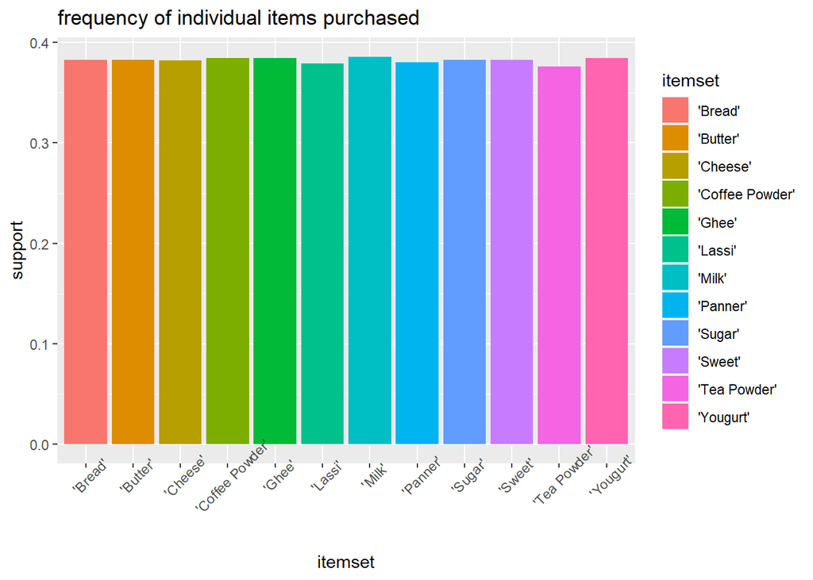

The above graph shows support, and that the support for all products is quite evenly distributed. For those unaware of the terminology used like support, confidence, and lift, these values represent:

# Support

# Confidence

The confidence identifies how likely the combination of items are, given that the first item is already chosen. A confidence of 15% for cheese and butter would represent that 15% of customers who selected cheese also purchased butter.

# Lift

the lift identifies how likely customers are to select both options together than either option alone.

[interactive table not shown]